# Shopify Project Demo

Hi! I’m Jacob, and this is my project demo for my Shopify Data Internship interview.

## Background

In my senior year of high school, I had an idea for a side project that I thought would be a lot of fun. I’m a big baseball fan, and having several friends who work in analytics for the Blue Jays, I’ve seen some incredible analysis done with baseball statistics.

What I wanted to do sounded relatively simple at first glance. A popular metric is Win Expectancy - at some point in a game, Home Team X might have a 53% chance of winning, for example. However, the most commonly used version of this metric defined “point in a game” by considering the inning, runners on base, and the score - it mostly considered win expectancy on an at-bat level. In essence, what the metric failed to capture was win expectancy on a *pitch level*. What I wanted to do was calculate the win expectancy given a state like this:

> Top 7, 1 out  
> 2-2 count  
> Bases loaded  
> Up by 5

This might seem like a small difference - all it’s doing is adding in the count! However, to me, that was a hugely important consideration; as a pitcher, I wanted to be able to analyze the differences in win expectancy caused between pitches, quantifying strategic decisions such as pitch selection. Take the above state and put yourself in the pitcher’s shoes. Do you throw a fastball? A curveball?

These questions are part of a much larger and ongoing debate in baseball, mostly spearheaded by a leading research named Mitchel Lichtman (co-author of [The Book: Playing The Percentages in Baseball](https://www.amazon.com/Book-Playing-Percentages-Baseball/dp/1494260174/ref=sr_1_1/147-7813119-0387312?ie=UTF8&qid=1519185109&sr=8-1&keywords=the+book+playing+the+percentages)), who helped me out a lot with this project. They’re deeply connected to many further questions about game theory, and they’re questions that I would love to investigate further one day using this research.

Before getting into the project, I’d like to note - some of this code is **awful**. Truly. When I opened the R files to assemble this notebook, *the code wasn’t even in the right order*. So, I readily admit that there lie many flaws in this notebook. I think that’s okay, though; no one’s first project is flawless, and even if people don’t tend to proceed to demo said project in an interview, it’s been enjoyable recognizing how I’ve grown (and how I’ve stayed the same) since I completed this.

## Process

I was going to group all games based on inning, outs, count, base state, and run differential, and then find the observed win percentage. Easy!

## Data Cleaning

**Wrong.** This was some of the messiest data in existence.

Upload it all to Google Cloud for faster queries and model training? Nope, it’s SQLite.

Clean, obvious structure? Nope, nulls *everywhere*.

### Creating base states

Before getting into any serious problems in the data, I started off with a quick and easy feature addition. Runners on base were denoted by either null, or the ID of the player on base. I changed this to simply be 0 (empty) or 1 (occupied) for each base.

```sql
ALTER TABLE pitch
ADD Occupied1b
DEFAULT 0;

ALTER TABLE pitch
ADD Occupied2b
DEFAULT 0;

ALTER TABLE pitch
ADD Occupied3b
DEFAULT 0;

UPDATE pitch
SET Occupied1b = 1
WHERE on_1b IS NOT NULL;

UPDATE pitch
SET Occupied2b = 1
WHERE on_2b IS NOT NULL;

UPDATE pitch
SET Occupied3b = 1
WHERE on_3b IS NOT NULL;
```

I could have simply altered the original columns to be `1 where not null` to be more space-efficient, but I chose to create new columns because I wanted to preserve the IDs of the runners on base for future analysis - perhaps, finding their speed and using that to estimate the change in win expectancy when attempting a steal.

As well, I edited the `gameday_link` column in `game` to simply append ‘gid_’ to the beginning. This was done for future join statements.

```sql
--Create ID to join game table
UPDATE game
SET gameday_link = 'gid_' || gameday_link;
```

### Fixing the score

The first major problem that stuck out to me was the fact that the score was NULL:NULL in almost every row. It took about a week an hour of staring at it before I realized that it was **only tracking the score on plays in which the score changed**. On one hand, I get it; that’s efficient. On the other hand, really?

```sql
ALTER TABLE atbat
ADD rownum
DEFAULT null;

UPDATE atbat
SET rownum = _ROWID_;
```

Note that `num` and `rownum` are distinct. `rownum` is the row’s location in the entire database, whereas `num` is the number of the play within a game (`1` would correspond to the first at-bat of a game).

`num` proved to be exceptionally helpful in this regard; we know that the score during the first at-bat will always be 0!

```sql
UPDATE atbat
SET home_team_runs = 0
WHERE num = 1;

UPDATE atbat
SET away_team_runs = 0
WHERE num = 1;
```

Now, at least, we have data that looks like:

```
0:0
NULL:NULL
...
1:0 (Scoring play occurs)
NULL:NULL
...
```

This makes things much easier; now it’s really a matter of bridging the gaps between the non-null values. Of course, these should just be the last non-null value (as it will only change on the *next* non-null value).

```sql
CREATE TABLE SortedData AS
    SELECT
       gameday_link, num, rownum, home_team_runs, away_team_runs
    FROM atbat
    ORDER BY atbat.gameday_link ASC, num ASC;

UPDATE SortedData
SET home_team_runs = (SELECT home_team_runs
             FROM SortedData AS sd2
             WHERE (sd2.num < SortedData.num AND sd2.home_team_runs IS NOT NULL)
             ORDER BY gameday_link DESC, num DESC
             LIMIT 1)
WHERE
    SortedData.home_team_runs IS NULL;

UPDATE SortedData
SET away_team_runs = (SELECT away_team_runs
             FROM SortedData AS sd2
             WHERE (sd2.num < SortedData.num AND sd2.away_team_runs IS NOT NULL)
             ORDER BY gameday_link DESC, num DESC
             LIMIT 1)
WHERE
    SortedData.away_team_runs IS NULL;
```

My solution was to create a new, sorted table, and to use it as a mask of sorts that held the `rownum` and the `home_team_runs / away_team_runs`. Then, we just have to combine the results:

```sql
UPDATE atbat
SET home_team_runs = (SELECT home_team_runs FROM SortedData WHERE atbat.rownum = SortedData.rownum);

UPDATE atbat
SET away_team_runs = (SELECT away_team_runs FROM SortedData WHERE atbat.rownum = SortedData.rownum);
```

### Constructing “time” remaining

Next, I wanted to calculate how many outs each team had remaining in the game. It was maybe more trouble than it was worth when considering extra innings (edge cases were a big problem overall in this project), but I wondered if it would give the model something a bit more definitive to predict on instead of the inning, if it was the “top or bottom,” and how many outs there were.

```sql
ALTER TABLE atbat
ADD off_rem_outs_h
DEFAULT NULL;

UPDATE atbat
SET off_rem_outs_h = 27-(inning*3)-3+o
WHERE inning_side = "bottom";

UPDATE atbat
SET off_rem_outs_h = 27-(inning-1)*3
WHERE inning_side = "top";

ALTER TABLE atbat
ADD def_rem_outs_h -- equivalent to away team's remaining outs
DEFAULT NULL;

UPDATE atbat
SET def_rem_outs_h = 27-((inning-1)*3)-o
WHERE inning_side = "top";

UPDATE atbat
SET def_rem_outs_h = 27-inning*3
WHERE inning_side = "bottom";
```

Forgive the magic numbers floating around. This is just a bit of algebraic fiddling to isolate for the outs remaining.

### Pulling it all together

Finally, I constructed this behemoth of a join. This essentially combines everything I’d created so far. I vividly remember having some kind of epiphany about the two inner join statements while I was on a 2 AM coding binge. Someone should have stopped me.

```sql
CREATE TABLE WinEx AS
SELECT DISTINCT p.inning_side AS side,
       p.inning AS inn,
       substr(p.count,1,1) AS b,
       substr(p.count,3,4) AS s,
       atbat.o AS out,
       p.Occupied1b AS state_1b,
       p.Occupied2b AS state_2b,
       p.Occupied3b AS state_3b,
       (CAST(atbat.home_team_runs AS INT) - CAST(atbat.away_team_runs AS INT)) AS rd,
       (CAST(SUM(game.homeW) AS float)/ CAST(COUNT( * ) AS float)) AS w_Pct,
       atbat.off_rem_outs_h AS off_r_outs,
       atbat.def_rem_outs_h AS def_r_outs,
       count( * ) AS n
  FROM pitch AS p
       INNER JOIN
       atbat ON (p.gameday_link = atbat.gameday_link AND
                 p.num = atbat.num)
       INNER JOIN
       game ON atbat.gameday_link = game.gameday_link
   --WHERE atbat.gameday_link = "gid_2010_04_02_chamlb_atlmlb_1" -- Testing on single game
 GROUP BY side,
          inn,
          count,
          out,
          Occupied1b,
          Occupied2b,
          Occupied3b,
          rd
 ORDER BY inn ASC,
          side DESC,
          rd ASC;
```

## Data Analysis

Finally! Done all the processing. So is that it? Am I done?

### Changing the process

After all of this, I thought I was finally done and could just lie back. A whole project done in nothing but SQL! So I opened up the table to take a look at my completed monster project.

What I realized was that I needed a way to estimate, rather than measure. So, I used a model.

### Choosing the model

Normally, the best practice would be to try several different models and find the best fit. However, I was a grade 12 student with no free time, patience, or will to carry on (senioritis). I decided I’d take the first model I saw that worked (a very scientific methodology).

I again got very lucky, stumbling on the randomForest library completely by chance. I had no idea what it meant or what it did - and to a reasonable extent I still don’t grasp every part of it - but my eyes had been opened to the existence of something beyond linear models. Using a random forest in this project is probably what directly led to my interest in machine learning today.

### Building the model

I’ll start off by loading our necessary libraries:

- RSQLite for fetching from our database
- Dplyr for data manipulation
- ggplot for data visualization
- randomForest for builing our model
- Metrics for statistical functions

```r
library(RSQLite)
library(dplyr)
library(ggplot2)
library(ggthemes)
library(randomForest)
library(Metrics)
```

First we’ll connect to our database, then create and fetch a query that grabs our cleaned data. We’ll then do one quick final processing step, converting our “Side” feature (Top or bottom of the inning) to a factor.

```r
db <- dbConnect(SQLite(), dbname = "PitchFX_08_17.sqlite3")

win_expectancy_query <- dbSendQuery(db, sql("SELECT *
                         FROM WinEx"))
data <- dbFetch(win_expectancy_query, n=-1)
data$side <- as.factor(data$side)
```

Then, we’ll partition our data into training and validation sets. After testing several values, I settled on a 65% / 35% split. While it’s obviously important to expose the model to sufficient training data, a decision tree runs a high risk of overfitting, so we can’t go too far overboard.

```r
rf_sample <- sample(2,
                    nrow(data),
                    replace = T,
                    prob = c(0.65,0.35))

training <- data[rf_sample==1,]
validation <- data[rf_sample==2,]
```

Now we get to the fun part! We’ll construct our Random Forest to model winning percentage as a function of all the features we worked so hard to combine in our SQL scripts.

```r
rf_model <- randomForest(formula = w_Pct ~ .,
                         data=training,
                         ntree=35,
                         weights=n
)
```

We can print out a summary of the model:

```r
print(rf_model)
```

```
Call:
 randomForest(formula = w_Pct ~ ., data = training, ntree = 35,      weights = n)
               Type of random forest: regression
                     Number of trees: 35
No. of variables tried at each split: 4

          Mean of squared residuals: 0.0181485
                    % Var explained: 90.43
```

It did really, really well! That’s an awesome fit for about 15 minutes of training (against about 130,000 examples and 13 or so features).

Here we see a comparison of the error against the number of trees. Having previously run this model with upwards of 50 trees, 35 trees seems to be the best trade off between computation time and accuracy. The error tends to level off around here.

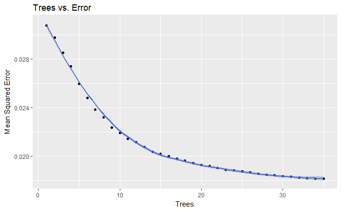

```r
qplot(c(1:length(rf_model$mse)), rf_model$mse,
      geom=c("point", "smooth"), main="Trees vs. Error",
      xlab="Trees", ylab="Mean Squared Error")
```

And here we see the inverse trend with $R^{2}$, just as you’d like to see - more variation explained as more trees are added.

Note that this is not the standard measure of $R^{2}$ - it is “pseudo”-$R^{2}$, calculated as $1 - \frac{mse}{var(y)}$. This is measuring the *variation* (spread of the data) explained, rather than the *variance* (shape of the distribution). I’ll just refer to pseudo-$R^{2}$ as $R^{2}$ for simplicity’s sake.

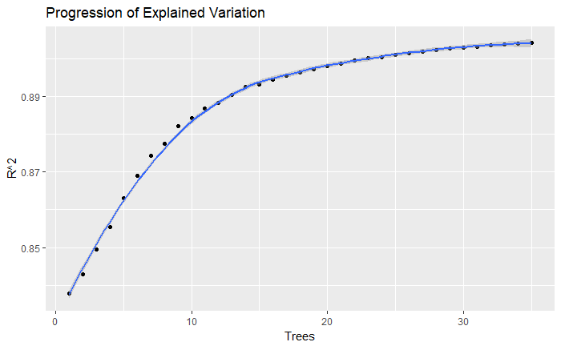

```r
qplot(c(1:length(rf_model$rsq)), rf_model$rsq,
      geom=c("point", "smooth"), main="Progression of Explained Variation",
      xlab="Trees", ylab="R^2")
```

When I first ran this in grade 12, I saw an $R^{2}$ of 91.92%. We get pretty close to that here. This means that my model was able to explain about 91% of the variation in observed win expectancy.

Of course, it’s important to verify these results on the validation set.

```r
validation$rf_W <- predict(rf_model, validation)
with(validation, 1-mse(w_Pct, rf_W)/var(w_Pct))
```

```
[1] 0.9095799
```

I’m not sure if it’s valid to then predict and/or re-train on the entire dataset (and neither is [r/datascience](https://www.reddit.com/r/datascience/comments/7xqszr/should_final_model_be_retrained_on_full_dataset/), apparently), so to err on the side of caution I’ll leave it at checking out the $R^{2}$ on the whole set without retraining.

```r
data$rf_W <- predict(rf_model, data)
with(data, 1-mse(w_Pct, rf_W)/var(w_Pct))
```

```
[1] 0.9465143
```

Almost 95%!! That’s really awesome. The measure is almost as accurate as the observed data, while minimizing many of the outlier scores that would affect future analysis.

## Conclusion

This was a super fun, super brutal project. It was my first big project, and taught me a ton of stuff that I still use today. I fully recognize that some of the code here is absolutely terrifying and should never again see the light of day, but it’s also kind of endearing to me. More than anything else, it was a passion project; can’t go wrong with that.